# report_0130

Fuyu Guo

1/30/2021

```r
table(df$round) %>% as.data.frame() %>% formattable(align = "c")
```

| Var1 | Freq |
| --- | --- |
| base | 501 |
| m1 | 464 |
| m2 | 428 |

## Measurements

- Main outcome: Sex-related knowledge (ranging from 0-11)
- Secondary outcome: GSES (General Self Efficacy Scale, ranging from 10-40, the higher, the better)
- Other indicators: Sex-related attitudes (To be finished)

## Methods

- Twish J. et al.(2018)
- Melanie Bell and Brooke Rabe (2020)

*Mixed effect modle*

- Mixed effect model: control school and students as random effect
- Fixed effect: sex, age(imputated), *hukou*, ethnicity, whether learned sex-related knowledge before, whether had romantic relationship before, whether had sex before

*All models sharing similar idea with DID*

- Repeated Measurements: All participants, even those who are lost in the follow-ups

adjust for baseline difference

$$Y_t = \beta_0 + +\beta1X + \beta_2dummytime_1 + \beta_3dummaytime_2 + \beta4 dummytime_1\times X + \beta5dummytime_2 \times X$$

not adjust for baseline difference

$$Y_t = \beta_0 + \beta_1dummytime_1 + \beta_2dummaytime_2 + \beta3 dummytime_1\times X + \beta4dummytime_2 \times X$$

$X$ indicates intervention

- Analysis of changes: Only those who could be tracked in the follow-ups

adjust for baseline difference

$$Y_t - Y_{t0} = \beta_0 + +\beta1X + \beta_2time + \beta_3Xtime$$

$$Y_t - Y_{t0} = \beta_0 + +\beta1X + \beta_2Y_{t0} + \beta_3time + \beta_4Xtime$$
$X$ indicates intervention; $time = 0$ indicates the first follow-up; $time = 1$ indicates the second follow-up

*KEY PROBLEM*

- I have not solved missing value problems

## Results

### Sex-related Knowledge

We used 11 questions to evaluate students’ sex-related knowledge.

```r
df$knowledge_score <- with(df, ifelse(D1 == 1, 1, 0)  +
                                   ifelse(D3 == 2, 1, 0) +
                                   ifelse(D4 == 2, 1, 0) +
                                   ifelse(D5 == 1, 1, 0) +
                                   ifelse(D7 == 2, 1, 0) +
                                   ifelse(D8 == 2, 1, 0) +
                                   ifelse(D10 == 1, 1, 0) +
                                   ifelse(D11 == 2, 1, 0) +
                                   ifelse(D13 == 2, 1, 0) +
                                   ifelse(D14 == 1, 1, 0) +
                                   ifelse(D15 == 1, 1, 0))
```

| round | intervention | mean | low_ci | up_ci |
| --- | --- | --- | --- | --- |
| base | control | 3.573840 | 3.298321 | 3.849358 |
| base | intervention | 3.060606 | 2.816739 | 3.304473 |
| m1 | control | 3.251142 | 2.925516 | 3.576767 |
| m1 | intervention | 6.485714 | 6.203495 | 6.767934 |
| m2 | control | 4.187166 | 3.856282 | 4.518049 |
| m2 | intervention | 5.601660 | 5.282347 | 5.920973 |

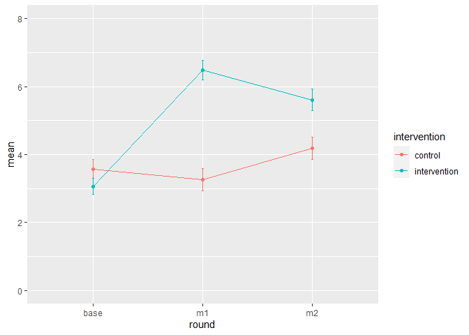

### Regression results

- Treatment effects was measured by the change of scores

| Model | First follow-up | Second follow-up |
| --- | --- | --- |
| Repeated measures with baseline adjusted | 3.14 (1.94, 4.33) | 1.50 (0.30, 2.71) |
| Repeated measures without baseline adjusted | 3.44 (3.00, 3.87) | 1.81 (1.36, 2.24) |
| Analysis of changes with baseline adjusted | 3.61 (2.40, 4.83) | 1.85 (0.58, 3.11) |
| Analysis of changes without baseline adjusted | 3.86 (2.78, 4.93) | 2.09 (0.97, 3.21) |

### GSES

| round | intervention | mean | low_ci | up_ci |
| --- | --- | --- | --- | --- |
| base | control | 26.72996 | 26.10388 | 27.35603 |
| base | intervention | 25.79167 | 25.20710 | 26.37623 |
| m1 | control | 26.42009 | 25.73566 | 27.10452 |
| m1 | intervention | 25.10204 | 24.44121 | 25.76287 |
| m2 | control | 26.42781 | 25.65035 | 27.20526 |
| m2 | intervention | 25.51037 | 24.84192 | 26.17883 |

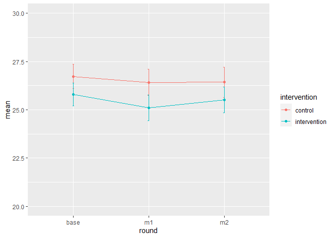

| Model | First follow-up | Second follow-up |
| --- | --- | --- |
| Repeated measures with baseline adjusted | -1.41 (-2.6, -0.22) | -1.02 (-2.24, 0.20) |
| Repeated measures without baseline adjusted | -0.89 (-1.87, 0.00) | -0.49 (-1.50, 0.42) |
| Analysis of changes with baseline adjusted | -1.65 (-2.59, -0.61) | 0.24 (-1.08, 1.55) |
| Analysis of changes without baseline adjusted | -1.82 (-2.86, -0.72) | 0.46 (-0.92, 1.85) |